# Assignment 1 - Dataset Selection & Initial Processing

###### Map to HUGO symbols

```r
# have to use CRAN mirror bcz of knitting issues
options(repos = "https://cran.stat.sfu.ca/")

install.packages("BiocManager")
##
## The downloaded binary packages are in
##  /var/folders/7y/r1nrzfmn5l3bs48t9_0yjcbr0000gn/T//RtmpriGdVS/downloaded_packages
BiocManager::install("ensembldb")
## Bioconductor version 3.18 (BiocManager 1.30.22), R 4.3.2 (2023-10-31)
## Warning: package(s) not installed when version(s) same as or greater than current; use
##   `force = TRUE` to re-install: 'ensembldb'
## Old packages: 'DBI', 'rvest', 'survival'
install.packages("biomaRt")
## Warning: package 'biomaRt' is not available for this version of R
##
## A version of this package for your version of R might be available elsewhere,
## see the ideas at
## https://cran.r-project.org/doc/manuals/r-patched/R-admin.html#Installing-packages
library(biomaRt)
ensembl_dataset <- "hsapiens_gene_ensembl"
ensembl <- useMart("ensembl", dataset = ensembl_dataset)
  #convert Human Ensembl Gene Ids to HGNC symbols
gene_id <- rownames(main_data_tbl)
id_conversion <- getBM(attributes = c("entrezgene_id","hgnc_symbol"),
                            filters = c("entrezgene_id"),
                            values = gene_id,
                            mart = ensembl)
entrez_symbol <- setNames(id_conversion$hgnc_symbol, id_conversion$entrezgene_id)
main_data_hugo <- main_data_tbl
rownames(main_data_hugo) <- entrez_symbol[rownames(main_data_hugo)]
knitr::kable(main_data_hugo[1:10,1:15], format = "html")
```

|  | Sample_01-H_dLCC | Sample_01-TI_Fe73 | Sample_01-TM_Fe6 | Sample_02-H_dRoDeAA | Sample_02-TM_ALVT33 | Sample_03-H_dZC | Sample_03-TITD_Fe46 | Sample_03-TM_Fe59 | Sample_04-H_dTG | Sample_04-TITD_Fe50 | Sample_04-TM_Fe8 | Sample_05-H_dPF | Sample_05-TITD_Fe80 | Sample_05-TM_Fe9 | Sample_06-H_dGiAg |
| --- | --- | --- | --- | --- | --- | --- | --- | --- | --- | --- | --- | --- | --- | --- | --- |
|  | 15 | 86 | 26 | 8 | 39 | 18 | 14 | 27 | 16 | 6 | 6 | 12 | 16 | 14 | 14 |
| NA | 1650 | 5320 | 785 | 652 | 1665 | 612 | 499 | 889 | 784 | 484 | 697 | 1798 | 1873 | 692 | 2082 |
| MIR6859-1 | 7 | 1 | 5 | 5 | 3 | 4 | 6 | 13 | 6 | 3 | 6 | 6 | 22 | 4 | 5 |
| NA | 1 | 22 | 1 | 2 | 4 | 0 | 1 | 2 | 1 | 0 | 0 | 1 | 2 | 1 | 2 |
| MIR1302-2 | 0 | 0 | 0 | 0 | 0 | 0 | 0 | 0 | 0 | 0 | 1 | 0 | 0 | 0 | 0 |
| FAM138A | 1 | 4 | 8 | 4 | 16 | 5 | 2 | 29 | 2 | 10 | 12 | 1 | 36 | 7 | 3 |
| OR4F5 | 0 | 0 | 0 | 0 | 0 | 0 | 0 | 0 | 0 | 0 | 0 | 0 | 0 | 0 | 0 |
| NA | 18 | 11 | 18 | 14 | 16 | 13 | 14 | 32 | 12 | 11 | 28 | 14 | 40 | 16 | 6 |
| NA | 154 | 169 | 196 | 187 | 61 | 158 | 152 | 147 | 96 | 76 | 521 | 184 | 366 | 96 | 244 |
|  | 9 | 19 | 29 | 5 | 37 | 26 | 16 | 35 | 20 | 4 | 5 | 4 | 13 | 16 | 3 |

```r
dim(main_data_hugo)
```

```
## [1] 39376    49
```

###### Data clean-up

**Remove Outliers and NA** Remove rows that were not able to map to symbols were assigned NA notation. They do have identifiers as numbers without a “prefix id”. In the future, mapping of such genes is possible.

```r
clean_data <- main_data_hugo[!is.na(rownames(main_data_hugo)) & !duplicated(rownames(main_data_hugo)),]
dim(clean_data)
## [1] 24601    49
```

Note that the gene number reduced with a difference of 14,775.

```r
  # get freq
gene_freq <- data.frame(Gene = rownames(clean_data), Freq = rowSums(clean_data))
knitr::kable(gene_freq[1:10,], format = "html")
```

|  | Gene | Freq |
| --- | --- | --- |
|  |  | 1577 |
| MIR6859-1 | MIR6859-1 | 416 |
| MIR1302-2 | MIR1302-2 | 12 |
| FAM138A | FAM138A | 1889 |
| OR4F5 | OR4F5 | 0 |
| MIR6859-2 | MIR6859-2 | 418 |
| OR4F29 | OR4F29 | 8 |
| MT-TS1 | MT-TS1 | 500042 |
| OR4F16 | OR4F16 | 48 |
| FAM87B | FAM87B | 121 |

```r
BiocManager::install("limma", force = TRUE) #have to force it bcz its not compatible with this version of R
## Bioconductor version 3.18 (BiocManager 1.30.22), R 4.3.2 (2023-10-31)
## Installing package(s) 'limma'
##
## The downloaded binary packages are in
##  /var/folders/7y/r1nrzfmn5l3bs48t9_0yjcbr0000gn/T//RtmpriGdVS/downloaded_packages
## Old packages: 'DBI', 'rvest', 'survival'
BiocManager::install("edgeR")
## Bioconductor version 3.18 (BiocManager 1.30.22), R 4.3.2 (2023-10-31)
## Warning: package(s) not installed when version(s) same as or greater than current; use
##   `force = TRUE` to re-install: 'edgeR'
## Old packages: 'DBI', 'rvest', 'survival'
library(edgeR)
## Loading required package: limma
##
## Attaching package: 'limma'
## The following object is masked from 'package:BiocGenerics':
##
##     plotMA
# keep counts that are >1 cpms and remove the rest
cpm_count <- cpm(clean_data)
 # 3 minimum samples
keep = rowSums(cpm_count >1) >=3
filtered_data = clean_data[keep, ]
dim(filtered_data)
## [1] 14072    49
```

Note. the number decreased even more.

```r
filtered_freq <- data.frame(Gene = rownames(filtered_data), Freq = rowSums(filtered_data))
knitr::kable(filtered_freq[1:10,], format = "html")
```

|  | Gene | Freq |
| --- | --- | --- |
|  |  | 1577 |
| FAM138A | FAM138A | 1889 |
| MT-TS1 | MT-TS1 | 500042 |
| LINC01128 | LINC01128 | 18320 |
| SAMD11 | SAMD11 | 19900 |
| NOC2L | NOC2L | 75999 |
| KLHL17 | KLHL17 | 6349 |
| PLEKHN1 | PLEKHN1 | 268 |
| HES4 | HES4 | 443 |
| ISG15 | ISG15 | 27489 |

### Apply Normalization

Use TMM to normalize counts

```r
library(edgeR)
# Create an edgeR container for RNASeq count data
d = DGEList(counts=filtered_data)

#calculate normalization factors
d = calcNormFactors(d)
#get the normalized data
normalized_counts <- cpm(d)

knitr::kable(normalized_counts[1:10,], format = "html")
```

|  | Sample_01-H_dLCC | Sample_01-TI_Fe73 | Sample_01-TM_Fe6 | Sample_02-H_dRoDeAA | Sample_02-TM_ALVT33 | Sample_03-H_dZC | Sample_03-TITD_Fe46 | Sample_03-TM_Fe59 | Sample_04-H_dTG | Sample_04-TITD_Fe50 | Sample_04-TM_Fe8 | Sample_05-H_dPF | Sample_05-TITD_Fe80 | Sample_05-TM_Fe9 | Sample_06-H_dGiAg | Sample_06-TITD_Fe28 | Sample_06-TM_Fe10 | Sample_07-H_dLePe | Sample_07-TI_Fe77 | Sample_07-TM_Fe29 | Sample_08-H_dNB | Sample_08-TM_AVLTU | Sample_09-H_tripletC | Sample_09-TITD_tripletC | Sample_09-TM_tripletC | Sample_10-H_tripletH | Sample_10-TI_tripletH | Sample_10-TM_tripletH | Sample_11-H_tripletQ | … |
| --- | --- | --- | --- | --- | --- | --- | --- | --- | --- | --- | --- | --- | --- | --- | --- | --- | --- | --- | --- | --- | --- | --- | --- | --- | --- | --- | --- | --- | --- | --- |
|  | 0.6521081 | 3.4327082 | 0.8545096 | 0.2797224 | 1.4369998 | 0.6734578 | 0.5778018 | 1.1867737 | 0.9444058 | 0.3220683 | 0.2471818 | 0.7401049 | 0.5430436 | 0.5275390 | 0.9846549 | 0.2903096 | 0.5789198 | 1.7481570 | 1.2603957 | 0.8031919 | 1.2335291 | 0.2272055 | 2.6834479 | 3.461605 | 2.4774038 | 2.7607448 | 3.7766827 | 3.445181 | 2.275636 | … |
| FAM138A | 0.0434739 | 0.1596608 | 0.2629260 | 0.1398612 | 0.5895384 | 0.1870716 | 0.0825431 | 1.2746829 | 0.1180507 | 0.5367805 | 0.4943637 | 0.0616754 | 1.2218481 | 0.2637695 | 0.2109975 | 0.2903096 | 0.4703723 | 0.0000000 | 0.5729071 | 0.0730174 | 0.1897737 | 0.1136027 | 3.6494891 | 5.044053 | 6.0558759 | 1.4045894 | 5.7405577 | 8.612954 | 1.861884 | … |
| MT-TS1 | 670.4541104 | 4325.1724565 | 305.6186502 | 381.6113277 | 594.8810507 | 167.6535719 | 190.1380509 | 235.6844746 | 410.5213962 | 224.8036670 | 190.9067699 | 575.1848834 | 260.9663871 | 209.4330005 | 602.7494397 | 230.3399483 | 192.0204643 | 757.5763283 | 329.4979944 | 231.7938843 | 1046.9815756 | 214.7091677 | 609.4646771 | 541.592853 | 594.0263725 | 429.2715947 | 766.8176499 | 856.797509 | 371.632048 | … |
| LINC01128 | 5.9124471 | 9.5796509 | 7.5262578 | 5.8392058 | 7.5534602 | 8.0440790 | 6.8510780 | 15.8236499 | 6.8469421 | 6.8707902 | 10.0932582 | 6.0441903 | 15.4767424 | 7.1217771 | 8.7915613 | 8.4189790 | 11.8316736 | 5.4942078 | 9.3956771 | 5.2207474 | 7.6858354 | 7.0812371 | 18.4621213 | 24.033430 | 27.6643422 | 23.5874158 | 26.5878460 | 20.479690 | 17.212083 | … |
| SAMD11 | 16.8678638 | 62.9462893 | 10.2541154 | 7.1678873 | 18.0914584 | 13.1698409 | 8.2130393 | 6.8129604 | 12.1592247 | 7.8906731 | 7.0446823 | 26.5821022 | 15.0355195 | 7.8754043 | 30.3133032 | 7.0503765 | 5.7530156 | 40.5822164 | 10.4651038 | 10.0033902 | 40.9911220 | 8.2551320 | 65.9054794 | 55.385683 | 54.5028831 | 13.2225144 | 37.1625575 | 27.848551 | 19.611845 | … |
| NOC2L | 52.5599157 | 87.9332120 | 75.2954433 | 51.4339622 | 60.9066817 | 90.4678279 | 78.1683239 | 65.6681472 | 59.6156161 | 74.7198435 | 70.4468227 | 64.8825324 | 85.9366487 | 69.1452962 | 86.9309577 | 63.2045519 | 50.4383884 | 79.1665390 | 58.2837533 | 102.6625300 | 70.2162739 | 78.6888273 | 105.7278455 | 114.430776 | 111.2079029 | 50.0808788 | 56.8013074 | 50.912127 | 62.642053 | … |
| KLHL17 | 8.2165625 | 13.6510025 | 3.4180385 | 2.4475713 | 1.9159997 | 3.8910894 | 3.9207977 | 4.0438216 | 5.6664348 | 4.5089561 | 5.0672276 | 15.1104757 | 9.0280997 | 2.4492884 | 5.4156017 | 4.0228619 | 4.0162562 | 10.4889421 | 6.6457229 | 4.3810468 | 8.0653828 | 4.4683742 | 7.2989782 | 4.846247 | 8.5332797 | 5.3761872 | 8.3087019 | 4.306477 | 3.889269 | … |
| PLEKHN1 | 0.6521081 | 2.4747431 | 0.3286575 | 0.0699306 | 0.3316153 | 0.1496573 | 0.1650862 | 0.1758183 | 0.2951268 | 0.3220683 | 0.5767576 | 0.9868066 | 0.3054620 | 0.1884068 | 0.4923274 | 0.3732552 | 0.1085475 | 0.9989469 | 0.2291629 | 0.2555611 | 0.2846606 | 0.4165434 | 0.2146758 | 0.197806 | 0.1376335 | 0.0484341 | 0.0000000 | 0.000000 | 0.000000 | … |
| HES4 | 2.5649587 | 0.3193217 | 0.0657315 | 0.1048959 | 0.0368461 | 0.2619002 | 0.2889009 | 0.0000000 | 1.5936848 | 0.1073561 | 0.0823939 | 3.8855509 | 0.1357609 | 0.1130441 | 1.4066498 | 0.1658912 | 0.1809124 | 2.7471039 | 0.2673567 | 0.0365087 | 6.6420800 | 0.2272055 | 1.1807171 | 0.494515 | 0.2752671 | 0.0484341 | 0.1510673 | 0.000000 | 0.413752 | … |
| ISG15 | 76.8618122 | 84.3009277 | 12.0617319 | 11.4686197 | 10.8696135 | 14.4419279 | 9.4924575 | 9.8018720 | 26.9745907 | 8.4811317 | 9.5576976 | 47.6750927 | 12.6257636 | 6.3304685 | 45.0127936 | 5.4744100 | 9.7330893 | 100.3941599 | 8.4408319 | 11.3907217 | 49.7207129 | 9.2018215 | 93.2766475 | 66.561722 | 64.2748647 | 10.2680332 | 82.3316823 | 57.419692 | 22.052982 | … |

```r
#apply normalization to freq data

d_filter = DGEList(counts=filtered_freq)
## Setting first column of `counts` as gene annotation.

#calculate normalization factors
d_filter = calcNormFactors(d_filter)
#get the normalized data
normalized_freq <- cpm(d_filter)

knitr::kable(normalized_freq[1:10,], format = "html")
```

|  | x |
| --- | --- |
|  | 1.4718410 |
| FAM138A | 1.7630360 |
| MT-TS1 | 466.6977428 |
| LINC01128 | 17.0983690 |
| SAMD11 | 18.5730100 |
| NOC2L | 70.9311653 |
| KLHL17 | 5.9256302 |
| PLEKHN1 | 0.2501290 |
| HES4 | 0.4134595 |
| ISG15 | 25.6559534 |

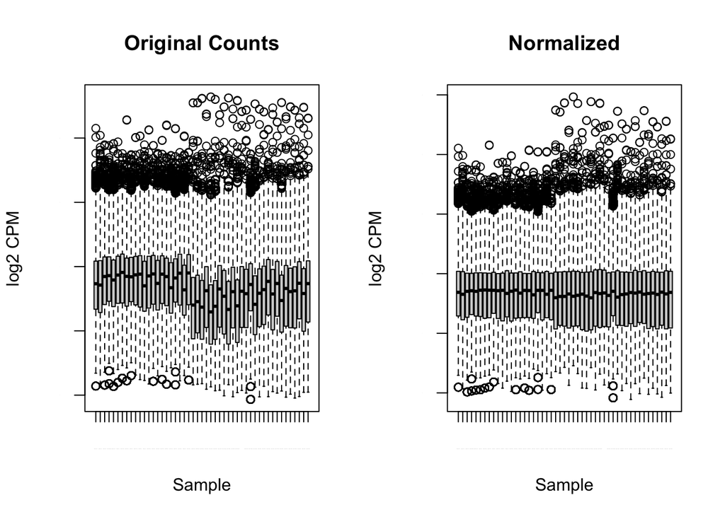

```r
# make box plots
library(edgeR)
par(mfrow=c(1, 2))

  # boxplot for original
boxplot(log2(edgeR::cpm(filtered_data)), main = "Original Counts",
        xlab = "Sample", ylab = "log2 CPM", cex.axis = 0.02)

  # boxplot for normalized
boxplot(log2(normalized_counts), main = "Normalized",
        xlab = "Sample", ylab = "log2 CPM", cex.axis = 0.02)
```

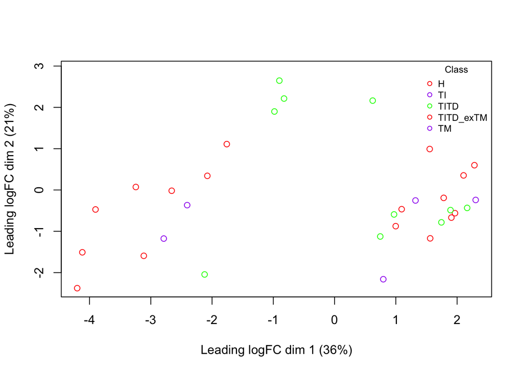

```r
# assign specific conditions
sample_info <- gsub("Sample_(\\d+)-(\\w+)_.*", "\\1-\\2", colnames(normalized_counts))
sample_num <- gsub("^(\\d+)-.*", "\\1", sample_info)
Condition <- gsub("^\\d+-(\\w+)$", "\\1", sample_info)

# MDS plot
mds_plot <- limma::plotMDS(d, labels = NULL, pch = 1,
                            col = c("red", "purple", "green")[factor(Condition)])
# Legend
legend("topright",
       legend = levels(factor(Condition)),
       pch = c(1), col = c("red", "purple", "green"),
       title = "Class",
       bty = 'n', cex = 0.75)
```

Note. The MDS represents the distance between samples based on the conditions.

### Interpretations and Observations

1. Why is the dataset of interest to you?
- β-thalassemia is a prevalent condition in South Asia (Hossain et al., 2017). Since I am from region, it has been a topic of interest to me. Furthermore, the presence of condition among my family members have also provided me with insight into lives of its carriers. Therefore, for this assignment I wanted to focus on this condition.
2. What are the control and test conditions of the data set?
- The control condition were healthy (H) participants while test conditons were Thalassemia Major (TM) and Thalassemia Intermedia (TI)
3. How many samples in each of the conditions of your dataset?
- H: 17 samples
- TM: 16 samples
- TI: 16 samples
4. Were there expression values that were not unique for specific genes? How did you handle these?
- Removing low count values helped with duplicates that can be classified as non-unique
5. Were there expression values that could not be mapped to current HUGO symbols?
- Yes, and they were removed. However, it was noted that just because they could not be mapped at present, there will always be a possibility that through updates mapping of such expression is possible
6. Were there any outliers in your dataset? How were they handled in the originating paper? How many outliers were removed?
- The original study handled outliers through statistical tests, Principal Component Analysis and removal of low quality samples (Nanou et al., 2021). In this report, anything less than 1 cpm count were removed.

7.How did you handle replicates? + Removal of duplicates (chunk 16) + Normalization - TMM

8. What is the final coverage of your dataset?
- 14,072

### References

Anders, S., McCarthy, D. J., Chen, Y., Okoniewski, M., Smyth, G. K., Huber, W., & Robinson, M. D. (2013). Count-based differential expression analysis of RNA sequencing data using R and Bioconductor. *Nature Protocols*, 8(9), Article 9. https://doi.org/10.1038/nprot.2013.099

Davis S, Meltzer P (2007). GEOquery: a bridge between the Gene Expression Omnibus (GEO) and BioConductor. *Bioinformatics*, 14, 1846–1847. https://doi.org/doi:10.18129/B9.bioc.GEOquery

Evans, C., Hardin, J., & Stoebel, D. M. (2018). Selecting between-sample RNA-Seq normalization methods from the perspective of their assumptions. *Briefings in Bioinformatics*, 19(5), 776–792. https://doi.org/10.1093/bib/bbx008

Hossain, M. S., Raheem, E., Sultana, T. A., Ferdous, S., Nahar, N., Islam, S., Arifuzzaman, M., Razzaque, M. A., Alam, R., Aziz, S., Khatun, H., Rahim, A., & Morshed, M. (2017). Thalassemias in South Asia: Clinical lessons learnt from Bangladesh. *Orphanet Journal of Rare Diseases*, 12, 93. https://doi.org/10.1186/s13023-017-0643-z

Robinson, M. D., & Oshlack, A. (2010). A scaling normalization method for differential expression analysis of RNA-seq data. *Genome Biology*, 11(3), R25. https://doi.org/10.1186/gb-2010-11-3-r25

Xie, Y., Allaire, J. J., & Grolemund, G. (2023). R Markdown: The Definitive Guide. *Chapman & Hall/CRC*. https://bookdown.org/yihui/rmarkdown/html-document.html